# Generalized Linear Models

Análise de dados com modelos lineares em R

Nicholas A. C. Marino

github.com/nacmarino/metodosR

## GLMs

- Implementado pela função `stats::glm` no R;
- Possui dois argumentos importantes:
  - *family*: determina qual distribuição que descreve a estrutura dos resíduos do modelo
  - *link*: determina como o **valor esperado** da variável resposta se relaciona com o modelo
- No geral, selecionamos `family` “à vontade”, mas não é recomendado alterar o `link`.

```r
args(glm)
```

```
## function (formula, family = gaussian, data, weights, subset,
##     na.action, start = NULL, etastart, mustart, offset, control = list(...),
##     model = TRUE, method = "glm.fit", x = FALSE, y = TRUE, contrasts = NULL,
##     ...)
## NULL
```

## GLMs | family & link

- Variável resposta é **contínua**:
  - gaussian: identity, log, sqrt, inverse
  - inverse.gaussian: identity, 1/mu^2, inverse, log
  - Gamma: reciprocal, identity, inverse, log
  - quasi: identity, logit, probit, cloglog, inverse, 1/mu^2, sqrt, power
- Variável resposta é **discreta**:
  - poisson: log, identity, sqrt
  - quasipoisson: identity, logit, probit, cloglog
  - binomial: logit, probit, cauchit, log, cloglog
  - quasibinomial: identity, log, profit, cloglog
  - negative binomial (MASS::glm.nb): identity, log, sqrt

## GLMs

- A escolha da família para a GLM vai depender da variável resposta.
  - Contínua ou categórica?
  - Contagens, razões, proporções?
  - Existem muitos valores “0”?
  - Qual o valor mínimo registrado para a variável resposta?
- O erro na seleção da família para o GLM é mais grave do que o erro de especificar uma função *link* errada.

## Overdispersion

- Qual o problema da overdispersion no contexto da GLM?
- Vamos simular um conjunto de dados.

```r
set.seed(33)
dados <- round((rnorm(n = 100, mean = 1500, sd = 600)))
dados
```

```
##   [1] 1418 1476 2106 1405  206 1799 1047 1967 1953  840 1600 1482 2626 1647
##  [15] 1921 1491 1414 1692 1573 1143 1235 1674 1934 1776 1611 1640 1856 2701
##  [29]  398  983 2450 1593 1335 1973 1366 2335 1207 1582 1502 1064 1067 1386
##  [43] 2301 1714 2006 1965 1548 1096 2601 1376 1176  600 1661 1521  903 1038
##  [57] 1153  940  194 1192 1553 1677 1915  533 1613 1546 1396  660 1278 1771
##  [71] 2476 2654 1402 1237 2215 2502 2180  590 3139 1800  605 2053 1190 2763
##  [85]  968 1399 2046  663 1988  926 1278 2387 1138 1326  429 2855 1100 1787
##  [99]  803 1272
```

## Overdispersion

- Qual o problema da overdispersion no contexto da GLM?

```r
library(fitdistrplus)
fitdist(dados, "pois")
```

```
## Fitting of the distribution ' pois ' by maximum likelihood
## Parameters:
##        estimate Std. Error
## lambda  1535.72   3.918795
```

```r
fitdist(dados, "norm")
```

```
## Fitting of the distribution ' norm ' by maximum likelihood
## Parameters:
##       estimate Std. Error
## mean 1535.7200   60.16470
## sd    601.6942   42.54615
```

## Overdispersion

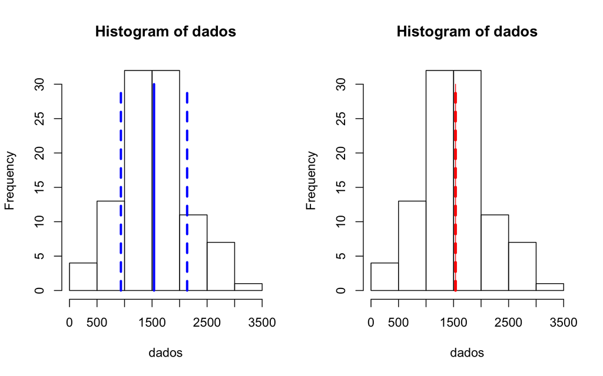

## Overdispersion

- A estimativa do erro de um parâmetro é **subestimada** - a distribuição estatística prevê que a dispersão do conjunto de dados é menor do que real.
- Outra forma de ver isso: os dados estão mais dispersos do que o esperado pela distribuição estatística.
- Ocorre principalmente quando tentamos utilizar a distribuição `poisson` ou `binomial` - ambas assumem que a variância é igual à média.
- No mundo real, os dados dificilmente segue esse mesmo pressuposto.
- A estimativa de um parâmetro torna-se muito precisa, mas o parâmetro passa a não descrever o conjunto de dados adequadamente.
- Muita atenção ao selecionar o tipo de distribuição para a variável resposta - diagnóstico e validação dos modelos é fundamental.

## De volta ao nosso exemplo

```r
ilhas <- read.table(file = "../model_selection/dados/ilhas.txt", header = TRUE)
modelo1 <- glm(log10(riqueza) ~ log10(area) + ilha + arquipelago, data = ilhas)
modelo1
```

```
##
## Call:  glm(formula = log10(riqueza) ~ log10(area) + ilha + arquipelago,
##     data = ilhas)
##
## Coefficients:
##        (Intercept)         log10(area)        ilhaoceanica
##             1.4723              0.1452             -0.4730
##   arquipelagomedio  arquipelagopequeno
##            -0.1879             -0.3912
##
## Degrees of Freedom: 79 Total (i.e. Null);  75 Residual
## Null Deviance:       9.073
## Residual Deviance: 0.8555    AIC: -124
```

## GLM | Distribuição de Poisson

- Usado principalmente para variável resposta discreta, como contagens.
- Todavia, também pode ser usado quando a variável resposta é contínua:
  - Taxas: por exemplo, evento ocorre em 5 de cada 1000 observações…
  - Proporções: por exemplo, 10 de cada 20 pessoas fazem…
  - Contagens por unidade: por exemplo, 14 indivíduos por m²…
- Em ecologia: utilizado para modelar dados de abundância e/ou densidade.

```r
modelo2 <- glm(riqueza ~ log10(area) + ilha + arquipelago, data = ilhas, family = poisson())
```

## GLM | Distribuição de Poisson

- Compare os coeficientes do modelo anterior com aquele previsto pelo modelo utilizando a distribuição de Poisson.

```r
modelo1$coefficients
```

```
##        (Intercept)        log10(area)       ilhaoceanica
##          1.4722607          0.1451749         -0.4729928
##   arquipelagomedio arquipelagopequeno
##         -0.1879321         -0.3912457
```

```r
modelo2$coefficients
```

```
##        (Intercept)        log10(area)       ilhaoceanica
##          3.3619482          0.3139392         -0.8500342
##   arquipelagomedio arquipelagopequeno
##         -0.4429848         -0.9026349
```

## GLM | Distribuição de Poisson

- A razão entre a **Deviance** e o **Residual df** pode dar uma estimativa do grau de **overdispersion** em um GLM com distribuição de Poisson.

```r
modelo2
```

```
##
## Call:  glm(formula = riqueza ~ log10(area) + ilha + arquipelago, family = poisson(),
##     data = ilhas)
##
## Coefficients:
##        (Intercept)         log10(area)        ilhaoceanica
##             3.3619              0.3139             -0.8500
##   arquipelagomedio  arquipelagopequeno
##            -0.4430             -0.9026
##
## Degrees of Freedom: 79 Total (i.e. Null);  75 Residual
## Null Deviance:       815
## Residual Deviance: 107.1     AIC: 493
```

## GLM | Distribuição de Poisson

- Se o valor de $\theta$ é maior do que 1, então existe evidência de **overdispersion** no modelo.

```r
theta <- modelo2$deviance/modelo2$df.residual
theta
```

```
## [1] 1.42792
```

## GLM | Distribuição de Poisson

- Soluções:
  1. Dividir os valores da variável resposta pelo valor de theta;
  2. Tentar outra função link;
  3. Tentar outra distribuição estatística - por exemplo, a família *quasi*;
  4. Transformar o dado original e usar a distribuição normal.
- Mas não perca a esperança: a distribuição de Poisson pode ser útil!

## GLM | Distribuição de Poisson

- Podemos utilizar a distribuição de Poisson para avaliar como o número de espécies de mamíferos varia em função das mesmas variáveis que havíamos analisado para a riqueza de espécies.
- Existe pouca evidência de que existe **overdispersion** nestes dados.

```r
modelo3 <- glm(mamiferos ~ log10(area) + ilha + arquipelago, data = ilhas, family = poisson())
modelo3$deviance/modelo3$df.residual
```

```
## [1] 0.1353488
```

## GLM | Distribuição de Poisson

- Uma forma de visualizar rapidamente os resultados do seu modelo (as predições) é através da função `visreg::visreg`.

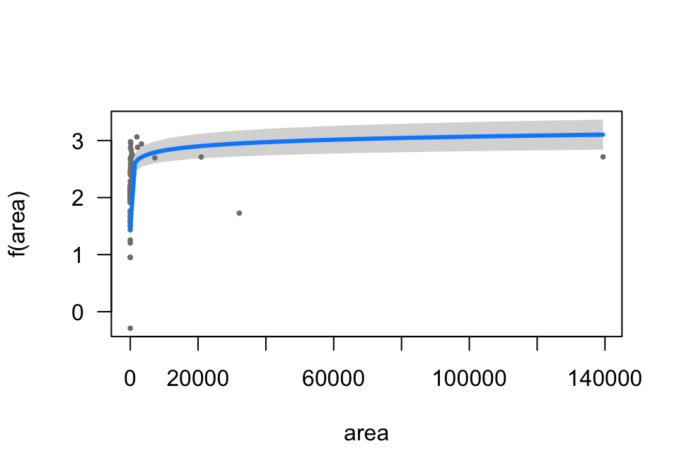

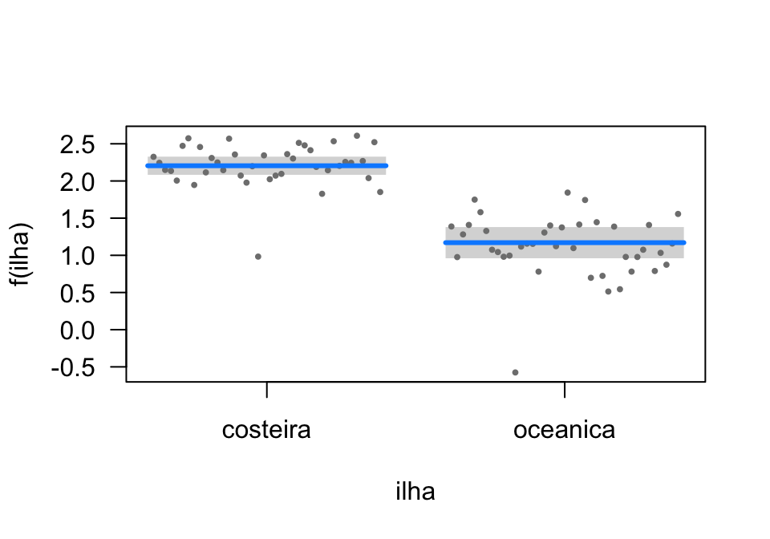

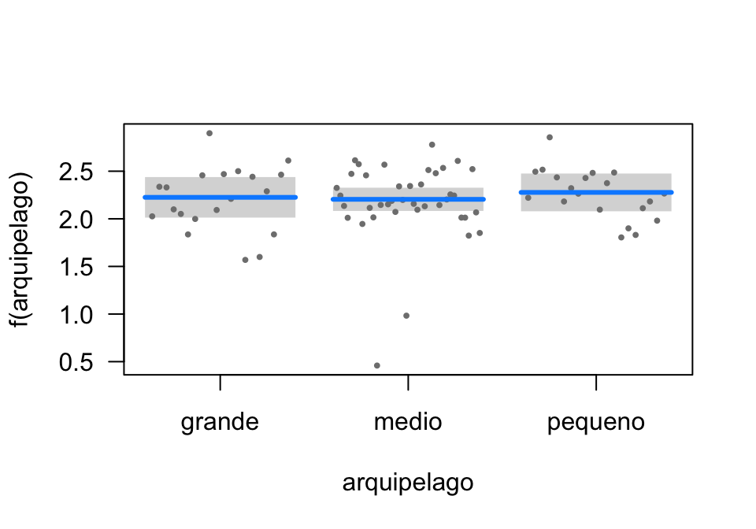

```r
library(visreg)
visreg(modelo3)
```

## GLM | Distribuição Binomial

- Utilizada principalmente para modelar probabilidades:
  - Qual a probabilidade do evento **x** ocorrer?
  - Como um fenômeno **x** varia em função de **y**?
- Sofre dos mesmo problemas da GLM com distribuição de Poisson.

## GLM | Distribuição Binomial

- Como a probabilidade de encontrarmos espécies de mamíferos muda com a área e tipo da ilha, e também do tamanho do arquipélago?

```r
modelo4 <- glm(cbind(riqueza, mamiferos) ~ log10(area) * ilha + arquipelago, data = ilhas, family = binomial())
modelo4
```

```
##
## Call:  glm(formula = cbind(riqueza, mamiferos) ~ log10(area) * ilha +
##     arquipelago, family = binomial(), data = ilhas)
##
## Coefficients:
##              (Intercept)               log10(area)
##                  1.61369                  -0.01504
##             ilhaoceanica          arquipelagomedio
##                 -0.23173                  -0.39368
##       arquipelagopequeno  log10(area):ilhaoceanica
##                 -0.92666                   0.18276
##
## Degrees of Freedom: 79 Total (i.e. Null);  74 Residual
## Null Deviance:       71.7
## Residual Deviance: 18.85     AIC: 290.1
```

```r
modelo4$deviance/modelo4$df.residual
```

```
## [1] 0.254727
```

## GLM | r<sup>2</sup>

```r
library(MuMIn)
r.squaredLR(modelo1)
```

```
## [1] 0.9057127
## attr(,"adj.r.squared")
## [1] 1.872208
```

```r
r.squaredLR(modelo2) # modelo com overdispersion
```

```
## [1] 0.9998565
## attr(,"adj.r.squared")
## [1] 0.9998568
```

```r
r.squaredLR(modelo3)
```

```
## [1] 0.8477816
## attr(,"adj.r.squared")
## [1] 0.8511671
```

```r
r.squaredLR(modelo4)
```

```
## [1] 0.4834444
## attr(,"adj.r.squared")
## [1] 0.49129
```

## Considerações finais

- Os GLMs são uma poderosa ferramenta para analisar os seus dados.
- A escolha da família e link para o GLM deve ser baseada na natureza do dado que você possui.
- O processo de criação, seleção e validação de modelo é o mesmo que o visto anteriormente.
- É bastante importante ficar atento à possibilidade de **overdispersion** no modelo, especialmente quando utilizar a distribuição de Poisson ou Binomial.